# ARIMA Forecasting: Temporal Inequality in Vaccination Progress

Eva Štětinová & Ayushman Mandhotra

2026-07-11

```r
knitr::opts_chunk$set(
  echo = TRUE, fig.width = 7.5, fig.height = 4.8,
  fig.path = "figures/pipeline/", dev = "png", dpi = 300
)

library(dplyr)
library(tidyr)
library(ggplot2)
library(forcats)
library(countrycode)
library(ggrepel)
library(ggdist)
library(ggbeeswarm)
library(ggcorrplot)
library(factoextra)
library(ggbreak)

Sys.setlocale("LC_TIME", "C")
```

```
## [1] "C"
```

```r
# ---- Colour palette (kept identical to arima.Rmd) -------------------------
teal_dark   <- "#015c6d"
teal_mid    <- "#017a8f"
teal_base   <- "#019ab5"
teal_light  <- "#4dc2d6"
teal_pale   <- "#a8e2ec"
teal_ghost  <- "#d9f2f6"

red_dark    <- "#c02200"
red_mid     <- "#fd300b"
red_base    <- "#fd5a38"
red_light   <- "#fe8a70"
red_pale    <- "#feb9a8"

country_colors <- c(
  "Germany" = teal_dark, "Spain" = teal_base, "Czechia" = teal_light,
  "Brazil"  = red_base,  "India" = red_light
)

continent_colors <- c(
  "Africa" = red_dark, "Asia" = red_base, "Oceania" = teal_light,
  "Americas" = teal_base, "Europe" = teal_dark
)

income_colors <- c(
  "High income" = teal_dark, "Upper middle income" = teal_base,
  "Lower middle income" = red_light, "Low income" = red_dark
)

theme_teal <- function() {
  theme_minimal() +
    theme(
      plot.title       = element_text(face = "bold", colour = "black"),
      plot.subtitle    = element_text(colour = "black"),
      axis.title       = element_text(colour = teal_dark),
      axis.text        = element_text(colour = "#555555"),
      legend.title     = element_text(colour = teal_dark, face = "bold"),
      legend.text      = element_text(colour = "#555555"),
      panel.grid.major = element_line(colour = teal_ghost),
      panel.grid.minor = element_blank()
    )
}
```

## Data Loading and Cleaning

The raw file is a standard comma-delimited CSV (Our World in Data’s public vaccinations export) with ordinary missing values encoded as empty cells. No non-standard delimiter or encoding correction is required or applied.

```r
vaccinations <- read.csv("vaccinations.csv", sep = ",", stringsAsFactors = FALSE)

vaccinations_clean <- vaccinations %>%
  mutate(
    date = as.Date(date),
    across(
      c(total_vaccinations_per_hundred,
        people_vaccinated_per_hundred,
        people_fully_vaccinated_per_hundred,
        total_boosters_per_hundred),
      ~ suppressWarnings(as.numeric(.x))
    )
  )

country_short_names <- c(
  "United Arab Emirates" = "UAE",
  "Democratic Republic of Congo" = "DRC",
  "Democratic Republic of the Congo" = "DRC",
  "United States" = "USA",
  "United Kingdom" = "UK",
  "Czech Republic" = "Czechia"
)

# countrycode's built-in "country.name" -> "continent" lookup does not
# recognise UK constituent countries or Kosovo/Timor-Leste, which produces
# a "not matched unambiguously" warning and silently drops these locations
# from every continent-coloured figure (Figure 11, Figure 13a). Supplying
# an explicit custom_match keeps them in, consistent with the iso3
# custom_match already used for the maps further down.
continent_custom_match <- c(
  "England" = "Europe", "Scotland" = "Europe", "Wales" = "Europe",
  "Kosovo" = "Europe", "Timor" = "Asia"
)
```

## Data Preparation

```r
regional_aggregates <- c(
  "World", "Europe", "European Union", "Asia", "Africa",
  "North America", "South America", "Oceania",
  "High income", "Upper middle income",
  "Lower middle income", "Low income"
)

vaccinations_country <- vaccinations_clean %>%
  filter(!location %in% regional_aggregates) %>%
  mutate(location = recode(location, !!!country_short_names, .default = location))

latest_country <- vaccinations_country %>%
  filter(!is.na(people_fully_vaccinated_per_hundred)) %>%
  group_by(location) %>%
  slice_max(date, n = 1) %>%
  ungroup() %>%
  mutate(continent = countrycode(location, origin = "country.name",
                                  destination = "continent",
                                  custom_match = continent_custom_match))

missing_country <- vaccinations_country %>%
  group_by(location) %>%
  summarise(
    missing_pct = mean(is.na(people_fully_vaccinated_per_hundred)) * 100,
    .groups = "drop"
  ) %>%
  arrange(desc(missing_pct))
```

The dataset covers 222 countries and territories (after excluding the 12 continent/income aggregate rows retained separately for group-level analysis), spanning December 02, 2020 to August 28, 2021. Of these, 216 countries have at least one non-missing full-vaccination record and form the basis of every cross-sectional (“latest observation”) comparison below.

**Comparability caveat.** “Latest observation” means each country’s own most recent non-missing record, not a fixed calendar date shared by all countries. These dates range from April 04, 2021 to August 28, 2021 — 15 of the 216 countries have a “latest” snapshot more than 30 days older than the true end of the observation window, meaning their true August 2021 position could be higher than what is plotted here. Every cross-sectional figure below (top/bottom lists, PCA, clustering, the continent comparison) inherits this limitation.

## Figure 1: Vaccination Trends in Selected Countries

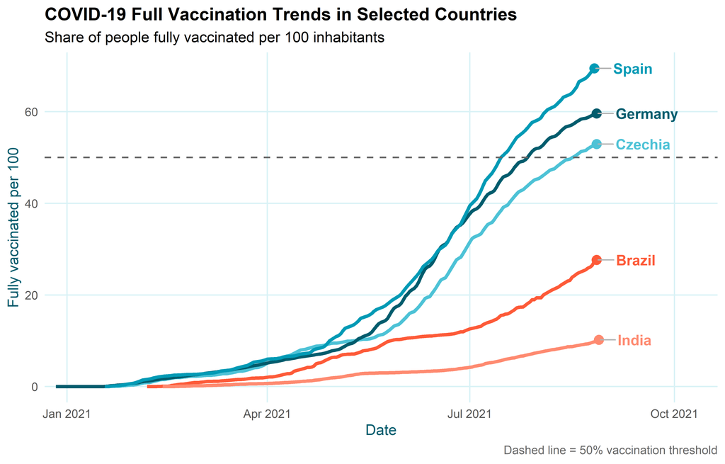

```r
selected_countries <- c("Spain", "Germany", "Czechia", "Brazil", "India")

plot_data <- vaccinations_country %>%
  filter(location %in% selected_countries,
         !is.na(people_fully_vaccinated_per_hundred))

last_points <- plot_data %>%
  group_by(location) %>%
  slice_max(date, n = 1) %>%
  ungroup()

ggplot(plot_data,
       aes(x = date, y = people_fully_vaccinated_per_hundred, colour = location)) +
  geom_line(linewidth = 1.2) +
  geom_point(data = last_points, size = 3) +
  geom_text_repel(
    data = last_points, aes(label = location),
    direction = "y", hjust = 0, nudge_x = 8, size = 3.8,
    fontface = "bold", segment.color = "grey70", show.legend = FALSE
  ) +
  geom_hline(yintercept = 50, linetype = "dashed", colour = "grey40", linewidth = 0.6) +
  scale_color_manual(values = country_colors) +
  scale_x_date(date_labels = "%b %Y", expand = expansion(mult = c(0.02, 0.18))) +
  labs(
    title    = "COVID-19 Full Vaccination Trends in Selected Countries",
    subtitle = "Share of people fully vaccinated per 100 inhabitants",
    x = "Date", y = "Fully vaccinated per 100",
    caption = "Dashed line = 50% vaccination threshold"
  ) +
  theme_teal() +
  theme(legend.position = "none", plot.caption = element_text(colour = "grey40"))
```

Figure 1 compares five countries — Spain, Germany, Czechia, Brazil, and India — chosen to span high-income European states and two larger middle/lower-middle-income countries. Spain, Germany, and Czechia show considerably faster rollout trajectories than Brazil and India; India remains clearly below the 50% threshold throughout the observation window.

## Figures 2 and 3: Top and Bottom 10 Countries (Latest Observation)

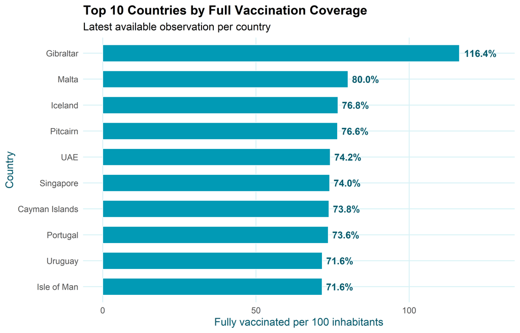

```r
top10 <- latest_country %>%
  arrange(desc(people_fully_vaccinated_per_hundred)) %>%
  slice_head(n = 10)

ggplot(top10, aes(x = reorder(location, people_fully_vaccinated_per_hundred),
                   y = people_fully_vaccinated_per_hundred)) +
  geom_col(fill = teal_base, width = 0.65, colour = "white", linewidth = 0.3) +
  geom_text(aes(label = sprintf("%.1f%%", people_fully_vaccinated_per_hundred)),
            hjust = -0.15, size = 3.5, colour = teal_dark, fontface = "bold") +
  coord_flip() +
  expand_limits(y = max(top10$people_fully_vaccinated_per_hundred) * 1.1) +
  labs(title = "Top 10 Countries by Full Vaccination Coverage",
       subtitle = "Latest available observation per country",
       x = "Country", y = "Fully vaccinated per 100 inhabitants") +
  theme_teal()
```

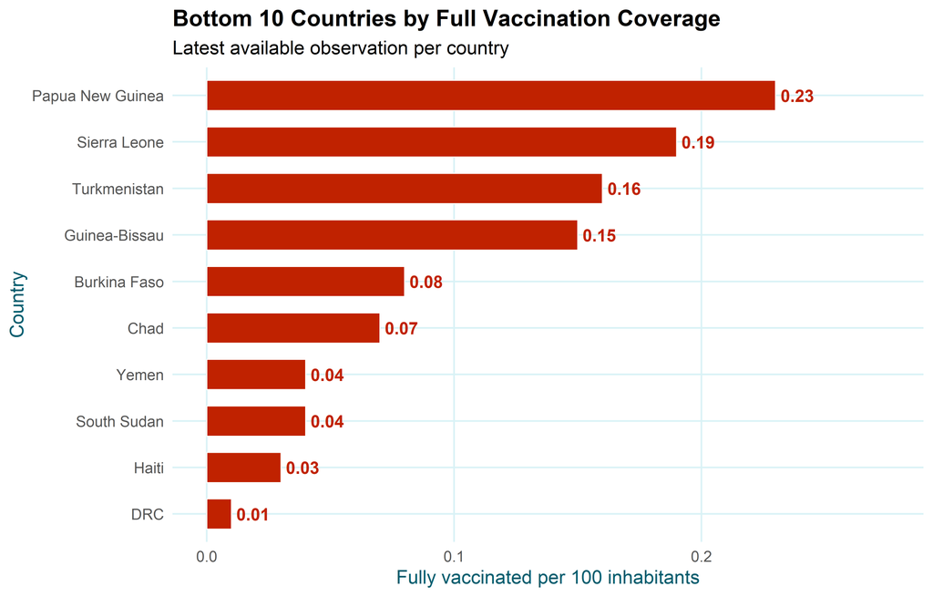

```r
bottom10 <- latest_country %>%
  arrange(people_fully_vaccinated_per_hundred) %>%
  slice_head(n = 10)

ggplot(bottom10, aes(x = reorder(location, people_fully_vaccinated_per_hundred),
                      y = people_fully_vaccinated_per_hundred)) +
  geom_col(fill = red_dark, width = 0.65, colour = "white", linewidth = 0.3) +
  geom_text(aes(label = sprintf("%.2f", people_fully_vaccinated_per_hundred)),
            hjust = -0.15, size = 3.5, colour = red_dark, fontface = "bold") +
  coord_flip() +
  expand_limits(y = max(bottom10$people_fully_vaccinated_per_hundred) * 1.2) +
  labs(title = "Bottom 10 Countries by Full Vaccination Coverage",
       subtitle = "Latest available observation per country",
       x = "Country", y = "Fully vaccinated per 100 inhabitants") +
  theme_teal()
```

The highest-coverage country, Gibraltar, reported 116.4 fully vaccinated per 100 inhabitants — a figure above 100 because it reflects vaccination of non-resident cross-border workers, not an error in the data. The lowest, DRC, reported 0.01, a ratio of roughly 11,640-fold between the two extremes.

## Figure 3b: Highest and Lowest Coverage, Side by Side (Broken Axis)

The gap between the highest- and lowest-coverage countries is large enough (more than three orders of magnitude) that a single linear axis cannot show both ends meaningfully. `ggbreak::scale_y_break()` compresses the unused middle of the range so both groups remain readable in one figure — an axis-break technique not covered in the course lectures.

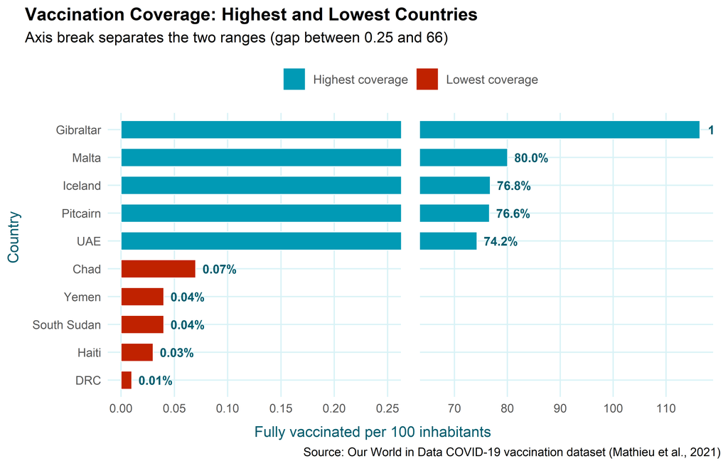

```r
top5 <- latest_country %>%
  arrange(desc(people_fully_vaccinated_per_hundred)) %>%
  slice_head(n = 5) %>%
  mutate(group = "Highest coverage")

bottom5 <- latest_country %>%
  arrange(people_fully_vaccinated_per_hundred) %>%
  slice_head(n = 5) %>%
  mutate(group = "Lowest coverage")

combined <- bind_rows(top5, bottom5) %>%
  mutate(location = reorder(location, people_fully_vaccinated_per_hundred),
         group = factor(group, levels = c("Highest coverage", "Lowest coverage")))

break_lower <- ceiling(max(bottom5$people_fully_vaccinated_per_hundred) * 4) / 4
break_upper <- floor(min(top5$people_fully_vaccinated_per_hundred) * 0.9)

ggplot(combined, aes(x = location, y = people_fully_vaccinated_per_hundred, fill = group)) +
  geom_col(width = 0.65, colour = "white", linewidth = 0.3) +
  geom_text(aes(label = ifelse(people_fully_vaccinated_per_hundred >= 1,
                                sprintf("%.1f%%", people_fully_vaccinated_per_hundred),
                                sprintf("%.2f%%", people_fully_vaccinated_per_hundred))),
            hjust = -0.2, size = 3.2, colour = teal_dark, fontface = "bold") +
  coord_flip() +
  scale_y_break(c(break_lower, break_upper), scales = 1, space = 0.5) +
  scale_fill_manual(values = c("Highest coverage" = teal_base, "Lowest coverage" = red_dark), name = NULL) +
  labs(title = "Vaccination Coverage: Highest and Lowest Countries",
       subtitle = paste0("Axis break separates the two ranges (gap between ",
                          break_lower, " and ", break_upper, ")"),
       x = "Country", y = "Fully vaccinated per 100 inhabitants",
       caption = "Source: Our World in Data COVID-19 vaccination dataset (Mathieu et al., 2021)") +
  theme_teal() + theme(legend.position = "top", legend.text = element_text(size = 9))
```

## Speed of Vaccination Rollout

```r
rollout_speed <- vaccinations_country %>%
  filter(!is.na(people_fully_vaccinated_per_hundred)) %>%
  group_by(location) %>%
  summarise(
    first_vaccination_date = min(date),
    reached_50 = any(people_fully_vaccinated_per_hundred >= 50),
    date_50 = ifelse(
      reached_50, min(date[people_fully_vaccinated_per_hundred >= 50]), NA
    ),
    date_50 = as.Date(date_50, origin = "1970-01-01"),
    days_to_50 = as.numeric(date_50 - first_vaccination_date),
    final_coverage = max(people_fully_vaccinated_per_hundred, na.rm = TRUE),
    .groups = "drop"
  )

n_reached <- sum(rollout_speed$reached_50)
n_total   <- nrow(rollout_speed)

cat(sprintf(
  "%d of %d countries (%.1f%%) reached 50%% full vaccination coverage.\n",
  n_reached, n_total, 100 * n_reached / n_total
))
```

```
## 61 of 216 countries (28.2%) reached 50% full vaccination coverage.
```

Of 216 countries with any reported full-vaccination data, only 61 (28.2%) reached the 50% threshold during the observation window; the remaining 155 (71.8%) did not.

## Figure 4: Fastest Countries to Reach 50% Coverage

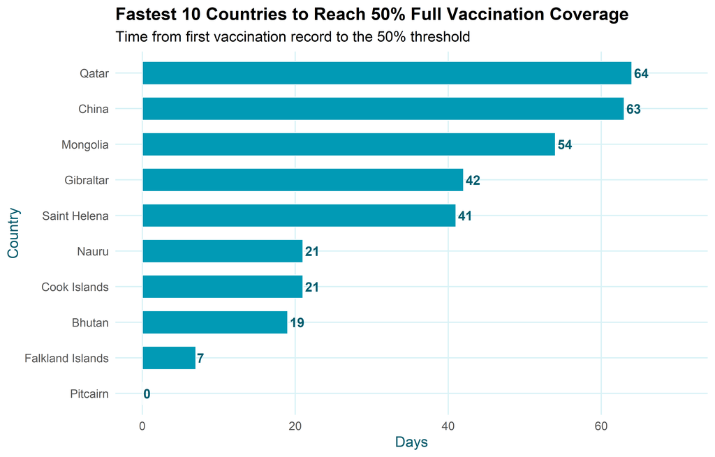

```r
fastest10 <- rollout_speed %>%
  filter(reached_50) %>%
  arrange(days_to_50) %>%
  slice_head(n = 10)

ggplot(fastest10, aes(x = reorder(location, days_to_50), y = days_to_50)) +
  geom_col(fill = teal_base, width = 0.65, colour = "white", linewidth = 0.3) +
  geom_text(aes(label = days_to_50), hjust = -0.15, size = 3.5,
             colour = teal_dark, fontface = "bold") +
  coord_flip() +
  expand_limits(y = max(fastest10$days_to_50) * 1.1) +
  labs(title = "Fastest 10 Countries to Reach 50% Full Vaccination Coverage",
       subtitle = "Time from first vaccination record to the 50% threshold",
       x = "Country", y = "Days") +
  theme_teal()
```

Figure 4 lists exactly the ten countries plotted above: Pitcairn, Falkland Islands, Bhutan, Cook Islands, Nauru, Saint Helena, Gibraltar, Mongolia, China, Qatar. Any country named in the discussion of rollout speed but not appearing in this list (for example, Israel, which reached the threshold in 72 days — still far faster than the 160-day median among the 61 countries that reached 50% at all, but outside this particular top-10 chart) is described separately and explicitly as such, rather than implied to be part of Figure 4.

## Figure 5: Distribution of Days to 50%

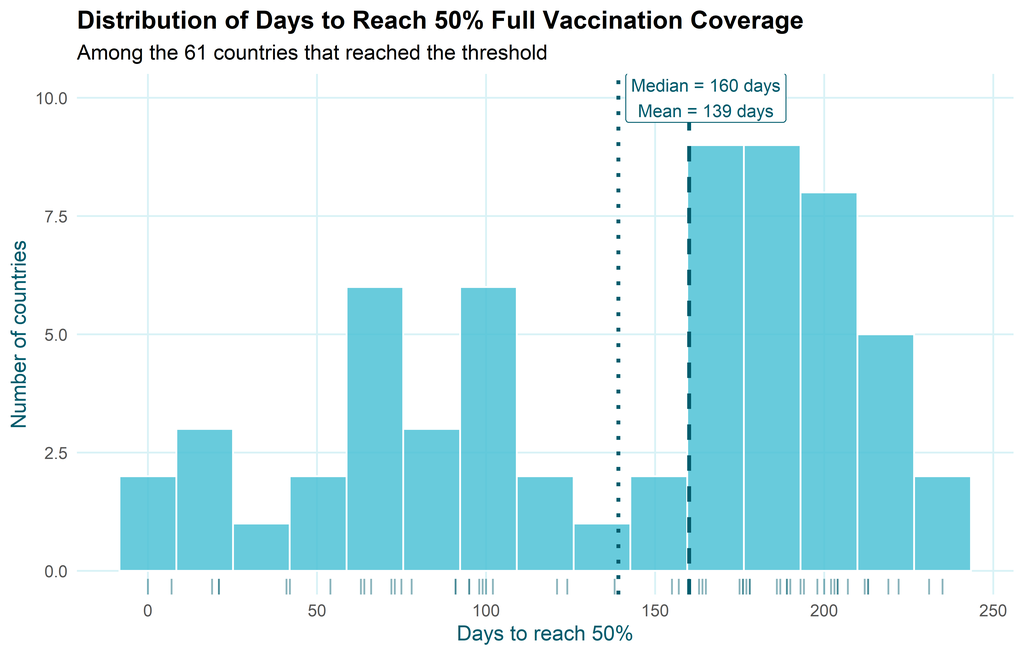

```r
days_50_data <- rollout_speed %>% filter(reached_50)
median_days <- median(days_50_data$days_to_50, na.rm = TRUE)
mean_days   <- mean(days_50_data$days_to_50, na.rm = TRUE)

ggplot(days_50_data, aes(x = days_to_50)) +
  geom_histogram(bins = 15, fill = teal_light, colour = "white", alpha = 0.85) +
  geom_vline(xintercept = median_days, linetype = "dashed", colour = teal_dark, linewidth = 1) +
  geom_vline(xintercept = mean_days, linetype = "dotted", colour = teal_dark, linewidth = 1) +
  annotate("label", x = median_days + 5, y = 10,
           label = paste0("Median = ", round(median_days), " days",
                          "\nMean = ", round(mean_days), " days"),
           fill = "white", colour = teal_dark, label.size = 0.2, size = 3.3) +
  geom_rug(sides = "b", colour = teal_dark, alpha = 0.45) +
  labs(title = "Distribution of Days to Reach 50% Full Vaccination Coverage",
       subtitle = paste0("Among the ", nrow(days_50_data), " countries that reached the threshold"),
       x = "Days to reach 50%", y = "Number of countries") +
  theme_teal()
```

## Figure 6: Lowest Observed Coverage Among Countries That Never Reached 50%

This figure differs from Figure 3 in one respect: Figure 3 ranks every country by its single *latest* observation (which, per the caveat above, can be a stale snapshot for some countries); Figure 6 instead uses each country’s *maximum ever recorded* value, and is restricted to the 155 countries that never reached the 50% threshold at any point in the series — a more conservative ranking for this specific group, less sensitive to reporting recency.

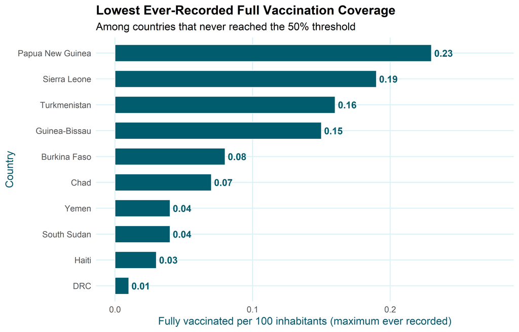

```r
lowest10 <- rollout_speed %>%
  filter(!reached_50) %>%
  arrange(final_coverage) %>%
  slice_head(n = 10)

ggplot(lowest10, aes(x = reorder(location, final_coverage), y = final_coverage)) +
  geom_col(fill = teal_dark, width = 0.65, colour = "white", linewidth = 0.3) +
  geom_text(aes(label = sprintf("%.2f", final_coverage)), hjust = -0.15,
            size = 3.5, colour = teal_dark, fontface = "bold") +
  coord_flip() +
  expand_limits(y = max(lowest10$final_coverage) * 1.2) +
  labs(title = "Lowest Ever-Recorded Full Vaccination Coverage",
       subtitle = "Among countries that never reached the 50% threshold",
       x = "Country", y = "Fully vaccinated per 100 inhabitants (maximum ever recorded)") +
  theme_teal()
```

## Figure 7: Missing Vaccination Data by Country

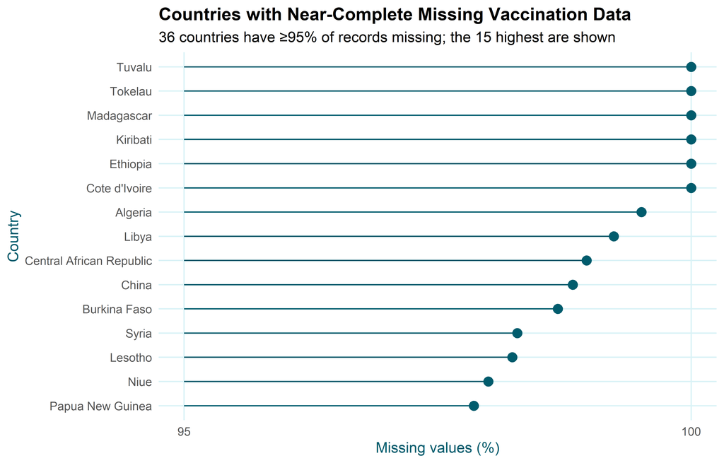

```r
n_high_missing <- sum(missing_country$missing_pct >= 95)

missing_country %>%
  filter(missing_pct >= 95) %>%
  slice_max(missing_pct, n = 15) %>%
  ggplot(aes(x = fct_reorder(location, missing_pct), y = missing_pct)) +
  geom_segment(aes(xend = location, y = 95, yend = missing_pct), colour = teal_dark) +
  geom_point(size = 3, colour = teal_dark) +
  coord_flip() +
  scale_y_continuous(limits = c(95, 100), breaks = seq(95, 100, 5)) +
  labs(title = "Countries with Near-Complete Missing Vaccination Data",
       subtitle = paste0(n_high_missing, " countries have ≥95% of records missing; the 15 highest are shown"),
       x = "Country", y = "Missing values (%)") +
  theme_teal()
```

36 countries have 95% or more missing full-vaccination records — the chart above shows only the 15 highest for readability, not the complete set. High missingness does not necessarily indicate the absence of a vaccination campaign: Tokelau, for example, is 100% missing from this dataset yet is reported elsewhere (ReliefWeb, 2021) to have achieved over 96% coverage of its eligible population. Countries with weaker administrative/digital reporting infrastructure are systematically underrepresented here, meaning the inequalities quantified in this notebook are, if anything, an underestimate.

## Geographic Data Preparation

Built once and reused for both maps below.

```r
library(sf)
library(rnaturalearth)

iso_custom_match <- c("England" = "GBR", "Scotland" = "GBR", "Wales" = "GBR",
                       "Kosovo" = "XKX", "Timor" = "TLS")

world <- ne_countries(scale = "medium", returnclass = "sf") %>%
  filter(admin != "Antarctica") %>%
  mutate(iso3 = ifelse(iso_a3 == "-99", adm0_a3, iso_a3))

coverage_map <- latest_country %>%
  mutate(iso3 = countrycode(location, origin = "country.name",
                             destination = "iso3c", custom_match = iso_custom_match)) %>%
  group_by(iso3) %>%
  summarise(people_fully_vaccinated_per_hundred = first(people_fully_vaccinated_per_hundred), .groups = "drop")

coverage_map_data <- world %>% left_join(coverage_map, by = "iso3")

speed_map <- rollout_speed %>%
  mutate(iso3 = countrycode(location, origin = "country.name",
                             destination = "iso3c", custom_match = iso_custom_match)) %>%
  filter(reached_50) %>%
  group_by(iso3) %>%
  summarise(days_to_50 = first(days_to_50), .groups = "drop")

speed_map_data <- world %>% left_join(speed_map, by = "iso3")
```

## Figure 8: World Map — Full Vaccination Coverage

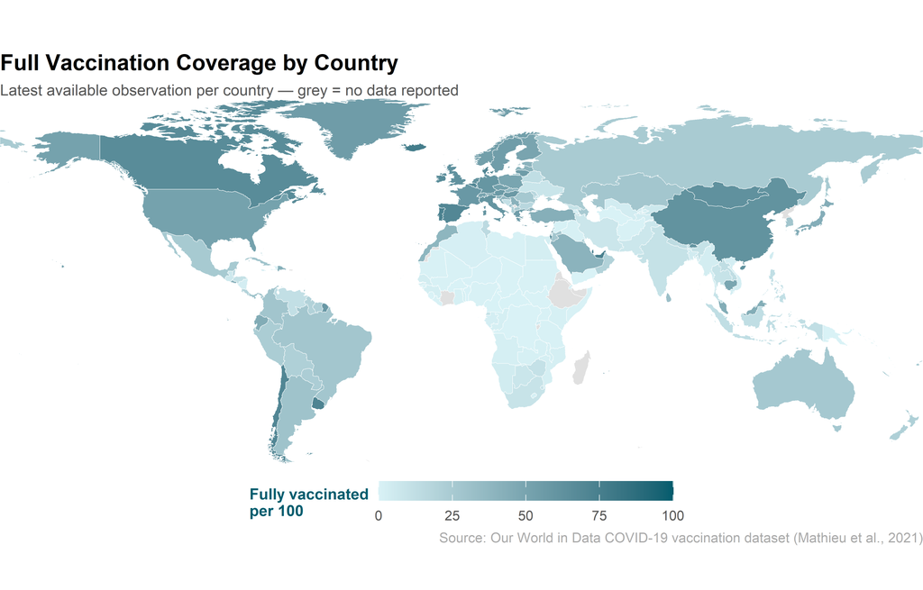

```r
ggplot(coverage_map_data) +
  geom_sf(aes(fill = people_fully_vaccinated_per_hundred), colour = "white", linewidth = 0.15) +
  scale_fill_gradient(low = teal_ghost, high = teal_dark, na.value = "grey88",
                       limits = c(0, 100), name = "Fully vaccinated\nper 100",
                       guide = guide_colorbar(barwidth = unit(12, "lines"), barheight = unit(0.8, "lines"))) +
  coord_sf(expand = FALSE) +
  labs(title = "Full Vaccination Coverage by Country",
       subtitle = "Latest available observation per country — grey = no data reported",
       caption = "Source: Our World in Data COVID-19 vaccination dataset (Mathieu et al., 2021)") +
  theme_void() +
  theme(plot.title = element_text(face = "bold", size = 13, colour = "black"),
        plot.subtitle = element_text(size = 9, colour = "#555555"),
        plot.caption = element_text(size = 8, colour = "#AAAAAA"),
        legend.position = "bottom", legend.direction = "horizontal",
        legend.title = element_text(colour = teal_dark, face = "bold", size = 9),
        legend.text = element_text(colour = "#555555", size = 8),
        plot.background = element_rect(fill = "white", colour = NA))
```

## Figure 9: World Map — Speed of Vaccination Rollout

This is the figure that the previous version of this notebook described in prose without ever actually producing. It uses `days_to_50` (defined above) rather than final coverage, so it captures speed specifically, distinct from Figure 8’s coverage snapshot.

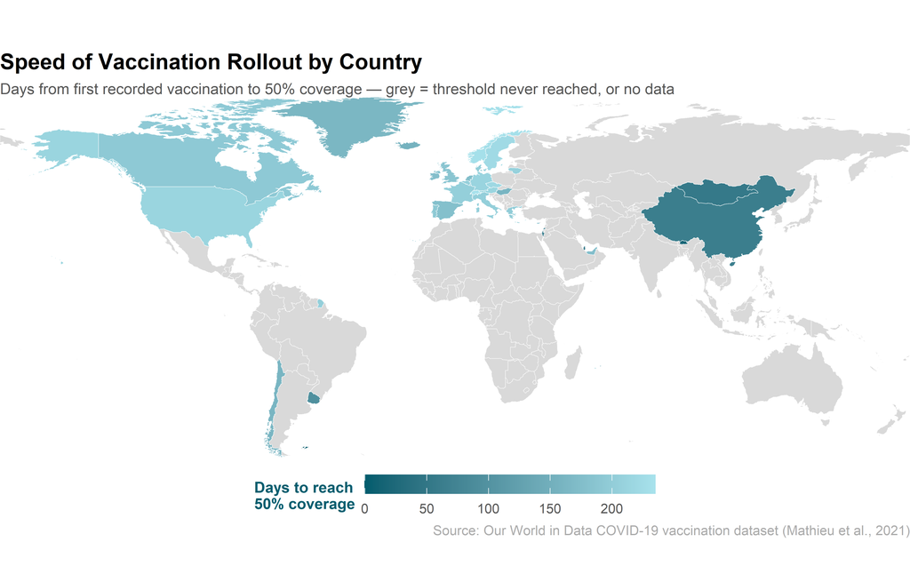

```r
ggplot(speed_map_data) +
  geom_sf(aes(fill = days_to_50), colour = "white", linewidth = 0.15) +
  scale_fill_gradient(low = teal_dark, high = teal_pale, na.value = "grey85",
                       name = "Days to reach\n50% coverage",
                       guide = guide_colorbar(barwidth = unit(12, "lines"), barheight = unit(0.8, "lines"))) +
  coord_sf(expand = FALSE) +
  labs(title = "Speed of Vaccination Rollout by Country",
       subtitle = "Days from first recorded vaccination to 50% coverage — grey = threshold never reached, or no data",
       caption = "Source: Our World in Data COVID-19 vaccination dataset (Mathieu et al., 2021)") +
  theme_void() +
  theme(plot.title = element_text(face = "bold", size = 13, colour = "black"),
        plot.subtitle = element_text(size = 9, colour = "#555555"),
        plot.caption = element_text(size = 8, colour = "#AAAAAA"),
        legend.position = "bottom", legend.direction = "horizontal",
        legend.title = element_text(colour = teal_dark, face = "bold", size = 9),
        legend.text = element_text(colour = "#555555", size = 8),
        plot.background = element_rect(fill = "white", colour = NA))
```

Darker shading indicates faster rollout; grey covers both the majority of countries that never reached the 50% threshold and countries with no usable data — the two are visually indistinguishable on this map, which is itself a limitation worth stating plainly rather than glossing over.

## Figure 10: Vaccination Coverage by Income Group Over Time

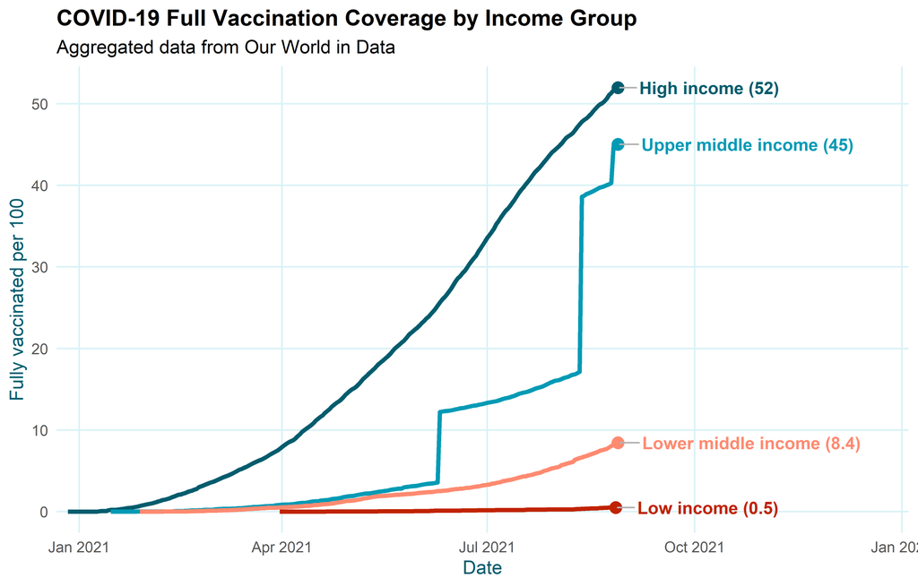

```r
income_group_levels <- c("High income", "Upper middle income",
                          "Lower middle income", "Low income")

vaccinations_income <- vaccinations_clean %>%
  filter(location %in% income_group_levels) %>%
  mutate(location = factor(location, levels = income_group_levels))

last_points_income <- vaccinations_income %>%
  filter(!is.na(people_fully_vaccinated_per_hundred)) %>%
  group_by(location) %>%
  slice_max(date, n = 1) %>%
  ungroup()

ggplot(vaccinations_income %>% filter(!is.na(people_fully_vaccinated_per_hundred)),
       aes(x = date, y = people_fully_vaccinated_per_hundred, colour = location)) +
  geom_line(linewidth = 1.2) +
  geom_point(data = last_points_income, size = 3) +
  geom_text_repel(
    data = last_points_income,
    aes(label = paste0(location, " (", round(people_fully_vaccinated_per_hundred, 1), ")")),
    direction = "y", hjust = 0, nudge_x = 8, size = 3.6, fontface = "bold",
    segment.color = "grey70", show.legend = FALSE
  ) +
  scale_color_manual(values = income_colors) +
  scale_x_date(date_labels = "%b %Y", expand = expansion(mult = c(0.02, 0.48))) +
  labs(title = "COVID-19 Full Vaccination Coverage by Income Group",
       subtitle = "Aggregated data from Our World in Data",
       x = "Date", y = "Fully vaccinated per 100") +
  theme_teal() + theme(legend.position = "none")
```

The gap between income groups widens continuously through the observation window; by August 2021, high-income countries had reached 52 fully vaccinated per 100, versus 0.5 for low-income countries.

## Figure 11: Vaccination Coverage by Continent

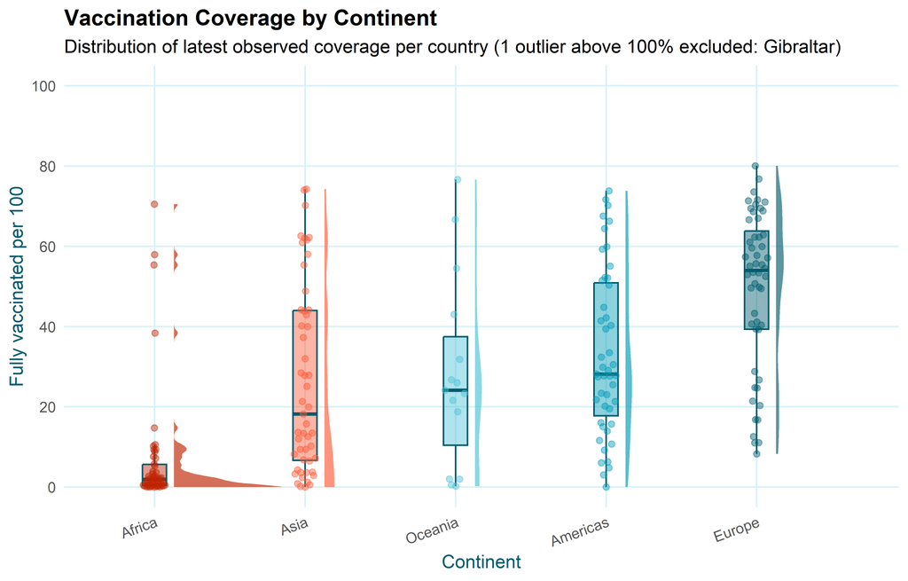

```r
n_excluded_outlier <- sum(latest_country$people_fully_vaccinated_per_hundred > 100, na.rm = TRUE)
excluded_names <- latest_country$location[latest_country$people_fully_vaccinated_per_hundred > 100]

latest_country %>%
  filter(!is.na(continent), !is.na(people_fully_vaccinated_per_hundred),
         people_fully_vaccinated_per_hundred <= 100) %>%
  mutate(continent = reorder(continent, people_fully_vaccinated_per_hundred, median)) %>%
  ggplot(aes(x = continent, y = people_fully_vaccinated_per_hundred, fill = continent, color = continent)) +
  ggdist::stat_halfeye(adjust = 0.7, width = 0.8, justification = -0.18, .width = 0,
                        point_colour = NA, alpha = 0.65) +
  geom_boxplot(width = 0.16, outlier.shape = NA, alpha = 0.45, colour = teal_dark) +
  ggbeeswarm::geom_quasirandom(width = 0.08, size = 1.5, alpha = 0.45, show.legend = FALSE) +
  scale_fill_manual(values = continent_colors) +
  scale_color_manual(values = continent_colors) +
  scale_y_continuous(limits = c(0, 100), breaks = seq(0, 100, 20)) +
  labs(title = "Vaccination Coverage by Continent",
       subtitle = paste0("Distribution of latest observed coverage per country (",
                          n_excluded_outlier, " outlier",
                          ifelse(n_excluded_outlier == 1, "", "s"),
                          " above 100% excluded: ", paste(excluded_names, collapse = ", "), ")"),
       x = "Continent", y = "Fully vaccinated per 100") +
  theme_teal() + theme(legend.position = "none", axis.text.x = element_text(angle = 20, hjust = 1))
```

The exclusion of Gibraltar (coverage above 100%, driven by cross-border vaccination) is stated explicitly in the subtitle above rather than left silent, since it slightly narrows Europe’s apparent spread.

## Figure 12: Correlation Matrix

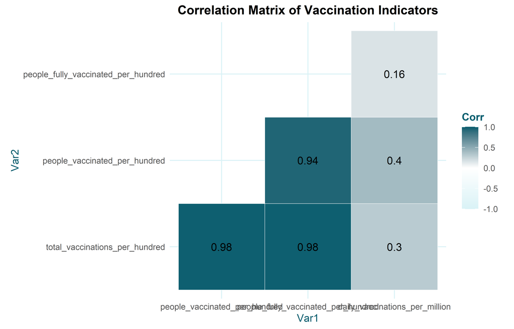

```r
correlation_data <- latest_country %>%
  select(total_vaccinations_per_hundred, people_vaccinated_per_hundred,
         people_fully_vaccinated_per_hundred, daily_vaccinations_per_million)

cor_matrix <- cor(correlation_data, use = "complete.obs")

ggcorrplot(cor_matrix, method = "square", type = "lower", lab = TRUE, lab_size = 4,
           colors = c(teal_ghost, "white", teal_dark), outline.col = "white",
           title = "Correlation Matrix of Vaccination Indicators") +
  theme_teal() + theme(legend.position = "right", plot.title = element_text(face = "bold", hjust = 0.5))
```

## Figure 13: PCA of Vaccination Indicators

```r
pca_input_all <- latest_country %>%
  select(location, total_vaccinations_per_hundred, people_vaccinated_per_hundred,
         people_fully_vaccinated_per_hundred, daily_vaccinations_per_million)

pca_input <- pca_input_all %>% na.omit()
n_dropped_pca <- nrow(pca_input_all) - nrow(pca_input)

pca_data <- pca_input %>% select(-location)
pca <- prcomp(pca_data, scale. = TRUE)
summary(pca)
```

```
## Importance of components:
##                           PC1    PC2     PC3     PC4
## Standard deviation     1.7489 0.9558 0.15412 0.06411
## Proportion of Variance 0.7646 0.2284 0.00594 0.00103
## Cumulative Proportion  0.7646 0.9930 0.99897 1.00000
```

```r
pca_scores <- as.data.frame(pca$x)
pca_scores$location <- pca_input$location
pca_scores$continent <- countrycode(pca_input$location, origin = "country.name",
                                     destination = "continent",
                                     custom_match = continent_custom_match)

loadings <- as.data.frame(pca$rotation) %>%
  tibble::rownames_to_column("variable") %>%
  mutate(variable = recode(variable,
    "people_fully_vaccinated_per_hundred" = "Fully vaccinated",
    "total_vaccinations_per_hundred"      = "Total doses",
    "people_vaccinated_per_hundred"       = "At least one dose",
    "daily_vaccinations_per_million"      = "Daily doses / million"
  ))
```

PCA was computed on the 209 countries with complete data across all four indicators (7 of 216 were excluded due to missing values in at least one indicator: Bonaire Sint Eustatius and Saba, Bulgaria, Eswatini, Hungary, Moldova, Philippines, Turkmenistan). The first component explains 76.5% of total variance, the second 22.8% — together 99.3%.

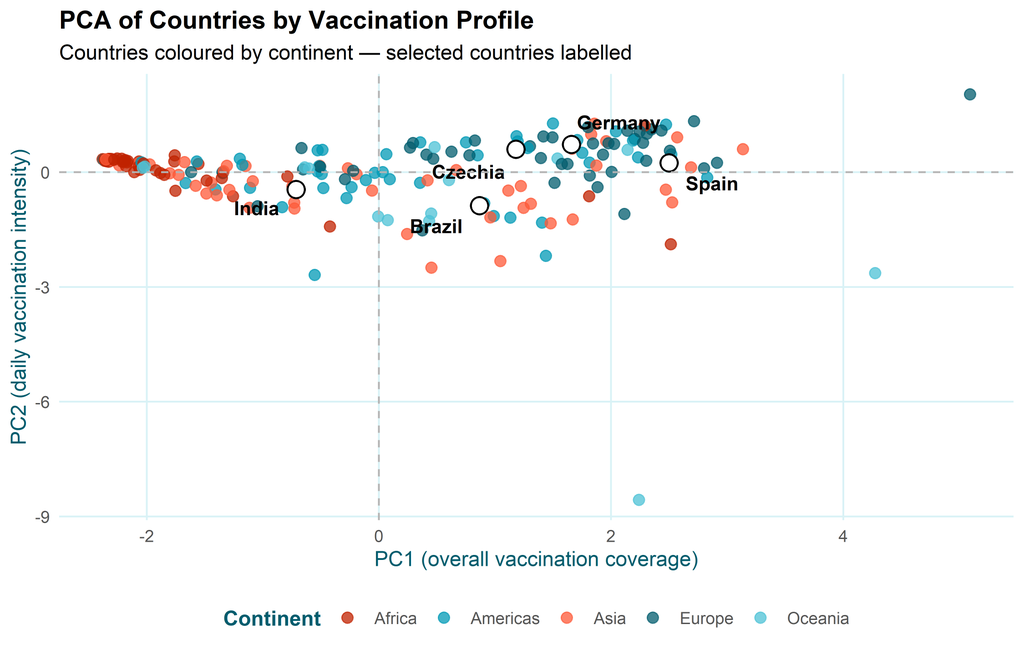

```r
label_countries <- c("Spain", "Germany", "Czechia", "Brazil", "India")

ggplot(pca_scores %>% filter(!is.na(continent)), aes(PC1, PC2)) +
  geom_point(aes(colour = continent), size = 2.5, alpha = 0.75) +
  geom_point(data = subset(pca_scores, location %in% label_countries),
             shape = 21, fill = "white", colour = "black", stroke = 0.8, size = 3.8) +
  geom_text_repel(data = subset(pca_scores, location %in% label_countries),
                   aes(label = location), size = 3.6, fontface = "bold",
                   box.padding = 0.5, point.padding = 0.3) +
  geom_hline(yintercept = 0, linetype = "dashed", colour = "grey70") +
  geom_vline(xintercept = 0, linetype = "dashed", colour = "grey70") +
  scale_colour_manual(values = continent_colors) +
  labs(title = "PCA of Countries by Vaccination Profile",
       subtitle = "Countries coloured by continent — selected countries labelled",
       x = "PC1 (overall vaccination coverage)", y = "PC2 (daily vaccination intensity)",
       colour = "Continent") +
  theme_teal() + theme(legend.position = "bottom")
```

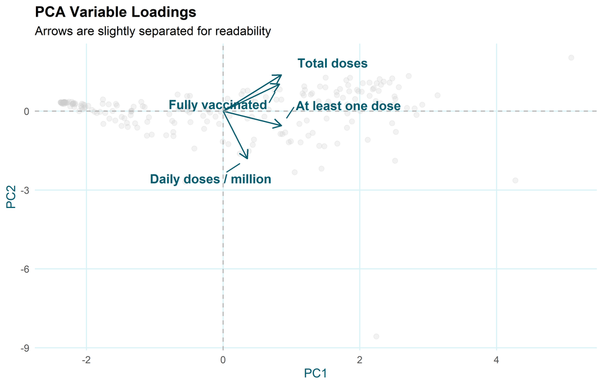

```r
loadings_plot <- loadings %>%
  mutate(
    PC1_plot = PC1 * 1.5,
    PC2_plot = case_when(
      variable == "Fully vaccinated"      ~ PC2 + 0.75,
      variable == "Total doses"           ~ PC2 + 1.25,
      variable == "At least one dose"     ~ PC2 - 0.55,
      variable == "Daily doses / million"  ~ PC2 - 0.85,
      TRUE ~ PC2
    )
  )

ggplot() +
  geom_point(data = pca_scores, aes(PC1, PC2), colour = "grey80", alpha = 0.25, size = 2) +
  geom_segment(data = loadings_plot, aes(x = 0, y = 0, xend = PC1_plot, yend = PC2_plot),
               arrow = arrow(length = unit(0.3, "cm")), colour = teal_dark, linewidth = 0.6) +
  geom_text_repel(data = loadings_plot, aes(PC1_plot, PC2_plot, label = variable),
                   colour = teal_dark, fontface = "bold", size = 4, force = 15,
                   max.overlaps = Inf, box.padding = 0.9, point.padding = 0.5) +
  geom_hline(yintercept = 0, linetype = "dashed", colour = "grey70") +
  geom_vline(xintercept = 0, linetype = "dashed", colour = "grey70") +
  labs(title = "PCA Variable Loadings", subtitle = "Arrows are slightly separated for readability",
       x = "PC1", y = "PC2") +
  theme_teal()
```

PC1 separates countries primarily by overall vaccination coverage (African and lower-income Asian countries cluster on the low end, European countries on the high end); the loadings plot shows the three cumulative indicators load together on PC1 while daily vaccinations per million loads mostly on PC2, nearly orthogonal to the cumulative measures.